# W3cubDocs

/Matplotlib 3.5

# matplotlib.pyplot.text

**matplotlib.pyplot.text(*x*, *y*, *s*, *fontdict=None*, **kwargs)[[source]](https://github.com/matplotlib/matplotlib/blob/v3.5.1/lib/matplotlib/pyplot.py#L2925-L2927)**

Add text to the Axes.

Add the text *s* to the Axes at location *x*, *y* in data coordinates.

**Parameters**

**x, y**float**

The position to place the text. By default, this is in data coordinates. The coordinate system can be changed using the *transform* parameter.

**s**str**

The text.

**fontdict**dict, default: None**

A dictionary to override the default text properties. If fontdict is None, the defaults are determined by `rcParams`.

**Returns**

**`Text`**

The created `Text` instance.

**Other Parameters**

**kwargs`Text` properties.**

Other miscellaneous text parameters.

| Property | Description |
| --- | --- |
| `agg_filter` | a filter function, which takes a (m, n, 3) float array and a dpi value, and returns a (m, n, 3) array |
| `alpha` | scalar or None |
| `animated` | bool |
| `backgroundcolor` | color |
| `bbox` | dict with properties for `patches.FancyBboxPatch` |
| `clip_box` | unknown |
| `clip_on` | unknown |
| `clip_path` | unknown |
| `color` or c | color |
| `figure` | `Figure` |
| `fontfamily` or family | {FONTNAME, 'serif', 'sans-serif', 'cursive', 'fantasy', 'monospace'} |
| `fontproperties` or font or font_properties | `font_manager.FontProperties` or [`str`](https://docs.python.org/3/library/stdtypes.html#str) or [`pathlib.Path`](https://docs.python.org/3/library/pathlib.html#pathlib.Path) |
| `fontsize` or size | float or {'xx-small', 'x-small', 'small', 'medium', 'large', 'x-large', 'xx-large'} |
| `fontstretch` or stretch | {a numeric value in range 0-1000, 'ultra-condensed', 'extra-condensed', 'condensed', 'semi-condensed', 'normal', 'semi-expanded', 'expanded', 'extra-expanded', 'ultra-expanded'} |
| `fontstyle` or style | {'normal', 'italic', 'oblique'} |
| `fontvariant` or variant | {'normal', 'small-caps'} |
| `fontweight` or weight | {a numeric value in range 0-1000, 'ultralight', 'light', 'normal', 'regular', 'book', 'medium', 'roman', 'semibold', 'demibold', 'demi', 'bold', 'heavy', 'extra bold', 'black'} |
| `gid` | str |
| `horizontalalignment` or ha | {'center', 'right', 'left'} |
| `in_layout` | bool |
| `label` | object |
| `linespacing` | float (multiple of font size) |
| `math_fontfamily` | str |
| `multialignment` or ma | {'left', 'right', 'center'} |
| `parse_math` | bool |
| `path_effects` | `AbstractPathEffect` |
| `picker` | None or bool or float or callable |
| `position` | (float, float) |
| `rasterized` | bool |
| `rotation` | float or {'vertical', 'horizontal'} |
| `rotation_mode` | {None, 'default', 'anchor'} |
| `sketch_params` | (scale: float, length: float, randomness: float) |
| `snap` | bool or None |
| `text` | object |
| `transform` | `Transform` |
| `transform_rotates_text` | bool |
| `url` | str |
| `usetex` | bool or None |
| `verticalalignment` or va | {'center', 'top', 'bottom', 'baseline', 'center_baseline'} |
| `visible` | bool |
| `wrap` | bool |
| `x` | float |
| `y` | float |
| `zorder` | float |

#### Examples

Individual keyword arguments can be used to override any given parameter:

```
>>> text(x, y, s, fontsize=12)
```

The default transform specifies that text is in data coords, alternatively, you can specify text in axis coords ((0, 0) is lower-left and (1, 1) is upper-right). The example below places text in the center of the Axes:

```
>>> text(0.5, 0.5, 'matplotlib', horizontalalignment='center',
...      verticalalignment='center', transform=ax.transAxes)
```

```
>>> text(x, y, s, bbox=dict(facecolor='red', alpha=0.5))
```

## Examples using `matplotlib.pyplot.text`

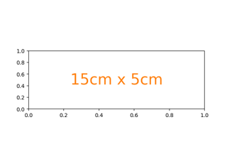

[Figure size in different units](https://matplotlib.org/3.5.1/gallery/subplots_axes_and_figures/figure_size_units.html#sphx-glr-gallery-subplots-axes-and-figures-figure-size-units-py)

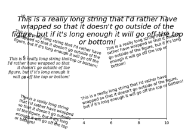

[Auto-wrapping text](https://matplotlib.org/3.5.1/gallery/text_labels_and_annotations/autowrap.html#sphx-glr-gallery-text-labels-and-annotations-autowrap-py)

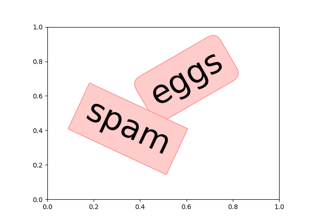

[Styling text boxes](https://matplotlib.org/3.5.1/gallery/text_labels_and_annotations/fancytextbox_demo.html#sphx-glr-gallery-text-labels-and-annotations-fancytextbox-demo-py)

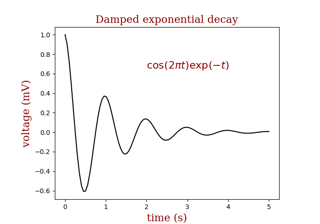

[Controlling style of text and labels using a dictionary](https://matplotlib.org/3.5.1/gallery/text_labels_and_annotations/text_fontdict.html#sphx-glr-gallery-text-labels-and-annotations-text-fontdict-py)

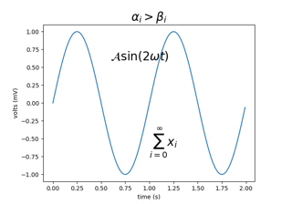

[Pyplot Mathtext](https://matplotlib.org/3.5.1/gallery/pyplots/pyplot_mathtext.html#sphx-glr-gallery-pyplots-pyplot-mathtext-py)

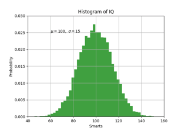

[Pyplot Text](https://matplotlib.org/3.5.1/gallery/pyplots/pyplot_text.html#sphx-glr-gallery-pyplots-pyplot-text-py)

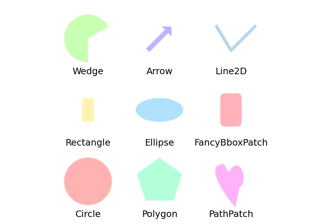

[Reference for Matplotlib artists](https://matplotlib.org/3.5.1/gallery/shapes_and_collections/artist_reference.html#sphx-glr-gallery-shapes-and-collections-artist-reference-py)

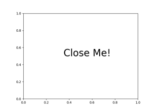

[Close Event](https://matplotlib.org/3.5.1/gallery/event_handling/close_event.html#sphx-glr-gallery-event-handling-close-event-py)

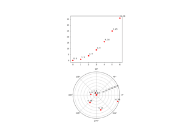

[transforms.offset_copy](https://matplotlib.org/3.5.1/gallery/misc/transoffset.html#sphx-glr-gallery-misc-transoffset-py)

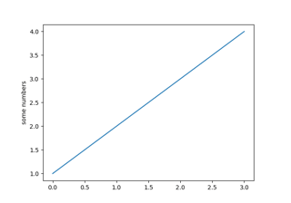

[Pyplot tutorial](https://matplotlib.org/3.5.1/tutorials/introductory/pyplot.html#sphx-glr-tutorials-introductory-pyplot-py)

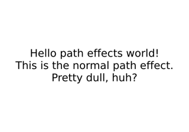

[Path effects guide](https://matplotlib.org/3.5.1/tutorials/advanced/patheffects_guide.html#sphx-glr-tutorials-advanced-patheffects-guide-py)

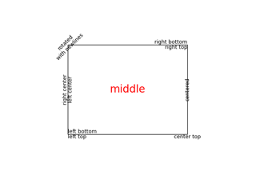

[Text properties and layout](https://matplotlib.org/3.5.1/tutorials/text/text_props.html#sphx-glr-tutorials-text-text-props-py)

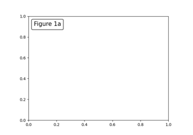

[Annotations](https://matplotlib.org/3.5.1/tutorials/text/annotations.html#sphx-glr-tutorials-text-annotations-py)

© 2012–2021 Matplotlib Development Team. All rights reserved.  
Licensed under the Matplotlib License Agreement.  
https://matplotlib.org/3.5.1/api/_as_gen/matplotlib.pyplot.text.html